# Estimating the effect of local police violence on mobility modality in Illinois

### Setting up framework for propensity score matching

Choosing confounders (all pre-treatment variables that aren’t the outcome variable) and variables of interest Variables to create new columns for: % men, % women, % voting age citizen:

```r
census_tracts_demographics_il_with_treatment_final <- census_tracts_demographics_il_with_treatment %>%
  mutate(perc_men = Men/TotalPop,
         perc_women = Women/TotalPop,
         perc_voting_age = VotingAgeCitizen/TotalPop)

census_tracts_demographics_il_with_treatment_final
```

| TractId | State | County | TotalPop | Men | Women | Hispanic | White | Black | Native | Asian | Pacific | VotingAgeCitizen | Income | IncomeErr | IncomePerCap | IncomePerCapErr | Poverty | ChildPoverty | Professional | Service | Office | Construction | Production | Drive | Carpool | Transit | Walk | OtherTransp | WorkAtHome | … |
| --- | --- | --- | --- | --- | --- | --- | --- | --- | --- | --- | --- | --- | --- | --- | --- | --- | --- | --- | --- | --- | --- | --- | --- | --- | --- | --- | --- | --- | --- | --- |
| 17001000100 | Illinois | Adams County | 4580 | 2105 | 2475 | 0.4 | 89.1 | 8.6 | 0.0 | 0.1 | 0.0 | 3688 | 48726 | 5656 | 29412 | 3804 | 5.0 | 1.1 | 29.2 | 25.6 | 25.8 | 9.5 | 9.9 | 81.9 | 12.3 | 0.0 | 0.6 | 0.0 | 5.1 | … |
| 17001000201 | Illinois | Adams County | 1911 | 886 | 1025 | 0.8 | 92.6 | 2.5 | 0.0 | 3.0 | 0.0 | 1487 | 41531 | 3541 | 22825 | 2088 | 15.6 | 21.7 | 37.3 | 16.9 | 28.0 | 6.3 | 11.6 | 79.5 | 10.1 | 4.0 | 0.5 | 0.6 | 5.3 | … |
| 17001000202 | Illinois | Adams County | 2473 | 1191 | 1282 | 0.6 | 91.1 | 5.8 | 0.0 | 0.4 | 0.0 | 1858 | 42750 | 7229 | 22753 | 3746 | 19.0 | 22.1 | 23.3 | 19.3 | 32.4 | 3.7 | 21.3 | 79.4 | 9.8 | 0.0 | 5.5 | 2.0 | 3.2 | … |
| 17001000400 | Illinois | Adams County | 3286 | 1540 | 1746 | 0.2 | 85.3 | 8.3 | 0.0 | 1.9 | 0.0 | 2671 | 29000 | 7114 | 19258 | 2358 | 30.4 | 46.5 | 22.1 | 27.9 | 28.7 | 8.5 | 12.8 | 73.2 | 14.9 | 0.0 | 3.9 | 4.4 | 3.6 | … |
| 17001000500 | Illinois | Adams County | 2346 | 1184 | 1162 | 1.7 | 77.4 | 19.0 | 0.0 | 0.0 | 0.0 | 1717 | 35136 | 6512 | 14855 | 1479 | 26.0 | 40.2 | 17.3 | 22.1 | 34.7 | 7.8 | 18.1 | 82.0 | 3.2 | 1.2 | 10.6 | 0.0 | 3.0 | … |
| 17001000600 | Illinois | Adams County | 3761 | 1927 | 1834 | 0.1 | 89.3 | 6.0 | 0.0 | 1.0 | 0.9 | 2909 | 44852 | 6718 | 32480 | 5036 | 13.7 | 28.2 | 36.6 | 17.4 | 20.5 | 5.4 | 20.2 | 85.6 | 4.3 | 0.8 | 2.8 | 1.4 | 5.1 | … |
| 17001000700 | Illinois | Adams County | 1193 | 688 | 505 | 2.2 | 81.7 | 13.9 | 1.3 | 0.9 | 0.0 | 1100 | 17832 | 2324 | 17476 | 2504 | 40.7 | 71.0 | 27.8 | 28.9 | 28.2 | 4.6 | 10.5 | 70.6 | 4.4 | 2.3 | 11.3 | 6.3 | 5.0 | … |
| 17001000800 | Illinois | Adams County | 2691 | 1214 | 1477 | 4.1 | 82.0 | 11.4 | 0.0 | 0.0 | 0.0 | 2019 | 24972 | 6291 | 16565 | 3303 | 40.3 | 51.4 | 9.2 | 42.2 | 29.3 | 5.1 | 14.3 | 65.5 | 9.6 | 5.4 | 12.8 | 0.8 | 6.0 | … |
| 17001000900 | Illinois | Adams County | 2756 | 1453 | 1303 | 0.7 | 93.1 | 3.1 | 0.0 | 0.0 | 0.0 | 2092 | 42848 | 6150 | 19410 | 2713 | 23.4 | 41.0 | 23.5 | 22.1 | 22.5 | 10.0 | 21.9 | 74.5 | 14.9 | 0.0 | 4.6 | 2.2 | 3.7 | … |
| 17001001001 | Illinois | Adams County | 3435 | 1661 | 1774 | 5.0 | 93.2 | 1.0 | 0.4 | 0.3 | 0.0 | 2535 | 52282 | 3279 | 25292 | 2377 | 11.3 | 16.3 | 20.7 | 18.1 | 32.6 | 10.5 | 18.1 | 84.4 | 9.9 | 0.0 | 0.0 | 2.3 | 3.4 | … |

[output cut: 990 more lines]

Treatment = mpv_treatment Dependent variable(s) = Mobility (Drive, Carpool, Transit, Walk, OtherTransp, WorkAtHome, MeanCommute) Explanatory variables = perc_men, perc_women, Hispanic, White, Black, Native, Asian, Pacific, perc_voting_age, Income, IncomePerCap, Poverty, ChildPoverty, Professional, Service, Office, Construction, Production, Employed, PrivateWork, PublicWork, SelfEmployed, FamilyWork, Unemployment

```r
# creating a dataset with just these variables above so we can focus
pscore_dataset <- census_tracts_demographics_il_with_treatment_final %>%
  select(mpv_treatment,Drive, Carpool, Transit, Walk, OtherTransp, WorkAtHome, MeanCommute, perc_men, perc_women, Hispanic, White, Black, Native, Asian, Pacific, perc_voting_age, Income, IncomePerCap, Poverty, ChildPoverty, Professional, Service, Office, Construction, Production, Employed, PrivateWork, PublicWork, SelfEmployed, FamilyWork, Unemployment)

pscore_data_clean <- na.omit(pscore_dataset) # get rid of NAs so that you can run matchit
dim(pscore_data_clean) # 3105 vs.
```

```
[1] 3105   32
```

## PScore analysis using MatchIt

Matching [parameters](https://www.rdocumentation.org/packages/MatchIt/versions/4.5.5/topics/matchit) to tune: - method: nearest, optimal, full, exact - distance: glm, mahalanobis

### Matching V1

```r
m.out1 <- matchit(mpv_treatment ~ perc_men + perc_women + Hispanic + White + Black + Native + Asian + Pacific + perc_voting_age + Income + IncomePerCap + Poverty + ChildPoverty + Professional + Service + Office + Construction + Production + Employed + PrivateWork + PublicWork + SelfEmployed + FamilyWork + Unemployment,
                  data = pscore_data_clean,
                  method = "nearest",
                  distance = "glm")

m.out1
```

```
A matchit object
 - method: 1:1 nearest neighbor matching without replacement
 - distance: Propensity score
             - estimated with logistic regression
 - number of obs.: 3105 (original), 244 (matched)
 - target estimand: ATT
 - covariates: perc_men, perc_women, Hispanic, White, Black, Native, Asian, Pacific, perc_voting_age, Income, IncomePerCap, Poverty, ChildPoverty, Professional, Service, Office, Construction, Production, Employed, PrivateWork, PublicWork, SelfEmployed, FamilyWork, Unemployment
```

```r
summary(m.out1)
```

```
Call:
matchit(formula = mpv_treatment ~ perc_men + perc_women + Hispanic +
    White + Black + Native + Asian + Pacific + perc_voting_age +
    Income + IncomePerCap + Poverty + ChildPoverty + Professional +
    Service + Office + Construction + Production + Employed +
    PrivateWork + PublicWork + SelfEmployed + FamilyWork + Unemployment,
    data = pscore_data_clean, method = "nearest", distance = "glm")

Summary of Balance for All Data:
                Means Treated Means Control Std. Mean Diff. Var. Ratio eCDF Mean eCDF Max
distance               0.0752        0.0378          0.6566     2.5225    0.2201   0.3336
perc_men               0.4745        0.4902         -0.3579     1.2386    0.0924   0.1733
perc_women             0.5255        0.5098          0.3579     1.2386    0.0924   0.1733
Hispanic              15.6590       15.9187         -0.0114     1.1328    0.0187   0.1077
White                 38.0787       61.2761         -0.6401     1.3056    0.2241   0.3173
Black                 41.7467       16.0161          0.6297     2.2648    0.2456   0.3366
Native                 0.1246        0.1165          0.0153     2.7639    0.0099   0.0686
Asian                  2.6123        4.7104         -0.3467     0.6267    0.0656   0.2884
Pacific                0.0131        0.0226         -0.1265     0.2817    0.0046   0.0209
perc_voting_age        0.7000        0.7109         -0.1038     1.0380    0.0418   0.0862
Income             46772.9918    64067.4589         -0.7304     0.5932    0.1864   0.3171
IncomePerCap       25096.7623    32282.2347         -0.4928     0.7866    0.1697   0.2783
Poverty               23.6975       15.0739          0.5611     1.5395    0.1554   0.3349
ChildPoverty          31.9402       19.7823          0.5371     1.5281    0.1649   0.3043
Professional          29.1762       35.5537         -0.4093     0.9916    0.0968   0.2493
Service               23.3492       18.5072          0.5196     1.3393    0.1169   0.3183
Office                24.5139       23.7486          0.1091     1.8307    0.0378   0.0876
Construction           6.3631        7.3933         -0.2421     0.8458    0.0485   0.0971
Production            16.6016       14.7970          0.2135     1.0119    0.0472   0.1209
Employed            1616.5738     2003.7764         -0.4155     0.7371    0.1088   0.1940
PrivateWork           82.0352       82.8112         -0.1151     0.9873    0.0278   0.1075
PublicWork            13.7303       12.2781          0.2126     1.1483    0.0463   0.1615
SelfEmployed           4.0975        4.7620         -0.2366     1.0406    0.0440   0.1275
FamilyWork             0.1344        0.1498         -0.0304     1.7472    0.0151   0.0914
Unemployment          13.1156        8.2344          0.5576     1.8474    0.1444   0.3359

Summary of Balance for Matched Data:
                Means Treated Means Control Std. Mean Diff. Var. Ratio eCDF Mean eCDF Max Std. Pair Dist.
distance               0.0752        0.0752          0.0001     1.0008    0.0003   0.0164          0.0016
perc_men               0.4745        0.4757         -0.0266     1.1854    0.0179   0.0738          0.9602
```

[output cut: 15 more lines]

```
Construction           6.3631        6.8967         -0.1254     0.7423    0.0370   0.1066          1.1091
Production            16.6016       16.1238          0.0565     0.9378    0.0224   0.0820          1.0767
Employed            1616.5738     1547.7787          0.0738     0.8326    0.0273   0.1066          0.9181
PrivateWork           82.0352       82.1287         -0.0139     0.8367    0.0168   0.0574          1.1316
PublicWork            13.7303       13.8098         -0.0116     0.8630    0.0213   0.0738          1.0377
SelfEmployed           4.0975        3.8992          0.0706     1.0860    0.0188   0.1066          1.0001
FamilyWork             0.1344        0.1598         -0.0503     1.4251    0.0159   0.0820          0.4946
Unemployment          13.1156       12.7566          0.0410     0.9387    0.0202   0.0984          0.6350

Sample Sizes:
          Control Treated
All          2983     122
Matched       122     122
Unmatched    2861       0
Discarded       0       0
```

### Matching V2

```r
m.out2 <- matchit(mpv_treatment ~ perc_men + perc_women + Hispanic + White + Black + Native + Asian + Pacific + perc_voting_age + Income + IncomePerCap + Poverty + ChildPoverty + Professional + Service + Office + Construction + Production + Employed + PrivateWork + PublicWork + SelfEmployed + FamilyWork + Unemployment,
                  data = pscore_data_clean,
                  method = "optimal",
                  distance = "glm")

m.out2
```

```
A matchit object
 - method: 1:1 optimal pair matching
 - distance: Propensity score
             - estimated with logistic regression
 - number of obs.: 3105 (original), 244 (matched)
 - target estimand: ATT
 - covariates: perc_men, perc_women, Hispanic, White, Black, Native, Asian, Pacific, perc_voting_age, Income, IncomePerCap, Poverty, ChildPoverty, Professional, Service, Office, Construction, Production, Employed, PrivateWork, PublicWork, SelfEmployed, FamilyWork, Unemployment
```

```r
summary(m.out2)
```

```
Call:
matchit(formula = mpv_treatment ~ perc_men + perc_women + Hispanic +
    White + Black + Native + Asian + Pacific + perc_voting_age +
    Income + IncomePerCap + Poverty + ChildPoverty + Professional +
    Service + Office + Construction + Production + Employed +
    PrivateWork + PublicWork + SelfEmployed + FamilyWork + Unemployment,
    data = pscore_data_clean, method = "optimal", distance = "glm")

Summary of Balance for All Data:
                Means Treated Means Control Std. Mean Diff. Var. Ratio eCDF Mean eCDF Max
distance               0.0752        0.0378          0.6566     2.5225    0.2201   0.3336
perc_men               0.4745        0.4902         -0.3579     1.2386    0.0924   0.1733
perc_women             0.5255        0.5098          0.3579     1.2386    0.0924   0.1733
Hispanic              15.6590       15.9187         -0.0114     1.1328    0.0187   0.1077
White                 38.0787       61.2761         -0.6401     1.3056    0.2241   0.3173
Black                 41.7467       16.0161          0.6297     2.2648    0.2456   0.3366
Native                 0.1246        0.1165          0.0153     2.7639    0.0099   0.0686
Asian                  2.6123        4.7104         -0.3467     0.6267    0.0656   0.2884
Pacific                0.0131        0.0226         -0.1265     0.2817    0.0046   0.0209
perc_voting_age        0.7000        0.7109         -0.1038     1.0380    0.0418   0.0862
Income             46772.9918    64067.4589         -0.7304     0.5932    0.1864   0.3171
IncomePerCap       25096.7623    32282.2347         -0.4928     0.7866    0.1697   0.2783
Poverty               23.6975       15.0739          0.5611     1.5395    0.1554   0.3349
ChildPoverty          31.9402       19.7823          0.5371     1.5281    0.1649   0.3043
Professional          29.1762       35.5537         -0.4093     0.9916    0.0968   0.2493
Service               23.3492       18.5072          0.5196     1.3393    0.1169   0.3183
Office                24.5139       23.7486          0.1091     1.8307    0.0378   0.0876
Construction           6.3631        7.3933         -0.2421     0.8458    0.0485   0.0971
Production            16.6016       14.7970          0.2135     1.0119    0.0472   0.1209
Employed            1616.5738     2003.7764         -0.4155     0.7371    0.1088   0.1940
PrivateWork           82.0352       82.8112         -0.1151     0.9873    0.0278   0.1075
PublicWork            13.7303       12.2781          0.2126     1.1483    0.0463   0.1615
SelfEmployed           4.0975        4.7620         -0.2366     1.0406    0.0440   0.1275
FamilyWork             0.1344        0.1498         -0.0304     1.7472    0.0151   0.0914
Unemployment          13.1156        8.2344          0.5576     1.8474    0.1444   0.3359

Summary of Balance for Matched Data:
                Means Treated Means Control Std. Mean Diff. Var. Ratio eCDF Mean eCDF Max Std. Pair Dist.
distance               0.0752        0.0752          0.0001     1.0008    0.0003   0.0164          0.0016
perc_men               0.4745        0.4757         -0.0266     1.1854    0.0179   0.0738          0.9729
```

[output cut: 15 more lines]

```
Construction           6.3631        6.8967         -0.1254     0.7423    0.0370   0.1066          1.1076
Production            16.6016       16.1238          0.0565     0.9378    0.0224   0.0820          1.0719
Employed            1616.5738     1547.7787          0.0738     0.8326    0.0273   0.1066          0.9086
PrivateWork           82.0352       82.1287         -0.0139     0.8367    0.0168   0.0574          1.1659
PublicWork            13.7303       13.8098         -0.0116     0.8630    0.0213   0.0738          1.0888
SelfEmployed           4.0975        3.8992          0.0706     1.0860    0.0188   0.1066          1.0007
FamilyWork             0.1344        0.1598         -0.0503     1.4251    0.0159   0.0820          0.4946
Unemployment          13.1156       12.7566          0.0410     0.9387    0.0202   0.0984          0.6350

Sample Sizes:
          Control Treated
All          2983     122
Matched       122     122
Unmatched    2861       0
Discarded       0       0
```

### Matching V3 - Best Performing Model

```r
m.out3 <- matchit(mpv_treatment ~ perc_men + perc_women + Hispanic + White + Black + Native + Asian + Pacific + perc_voting_age + Income + IncomePerCap + Poverty + ChildPoverty + Professional + Service + Office + Construction + Production + Employed + PrivateWork + PublicWork + SelfEmployed + FamilyWork + Unemployment,
                  data = pscore_data_clean,
                  method = "full",
                  distance = "glm")

m.out3
```

```
A matchit object
 - method: Optimal full matching
 - distance: Propensity score
             - estimated with logistic regression
 - number of obs.: 3105 (original), 3105 (matched)
 - target estimand: ATT
 - covariates: perc_men, perc_women, Hispanic, White, Black, Native, Asian, Pacific, perc_voting_age, Income, IncomePerCap, Poverty, ChildPoverty, Professional, Service, Office, Construction, Production, Employed, PrivateWork, PublicWork, SelfEmployed, FamilyWork, Unemployment
```

```r
summary(m.out3)
```

```
Call:
matchit(formula = mpv_treatment ~ perc_men + perc_women + Hispanic +
    White + Black + Native + Asian + Pacific + perc_voting_age +
    Income + IncomePerCap + Poverty + ChildPoverty + Professional +
    Service + Office + Construction + Production + Employed +
    PrivateWork + PublicWork + SelfEmployed + FamilyWork + Unemployment,
    data = pscore_data_clean, method = "full", distance = "glm")

Summary of Balance for All Data:
                Means Treated Means Control Std. Mean Diff. Var. Ratio eCDF Mean eCDF Max
distance               0.0752        0.0378          0.6566     2.5225    0.2201   0.3336
perc_men               0.4745        0.4902         -0.3579     1.2386    0.0924   0.1733
perc_women             0.5255        0.5098          0.3579     1.2386    0.0924   0.1733
Hispanic              15.6590       15.9187         -0.0114     1.1328    0.0187   0.1077
White                 38.0787       61.2761         -0.6401     1.3056    0.2241   0.3173
Black                 41.7467       16.0161          0.6297     2.2648    0.2456   0.3366
Native                 0.1246        0.1165          0.0153     2.7639    0.0099   0.0686
Asian                  2.6123        4.7104         -0.3467     0.6267    0.0656   0.2884
Pacific                0.0131        0.0226         -0.1265     0.2817    0.0046   0.0209
perc_voting_age        0.7000        0.7109         -0.1038     1.0380    0.0418   0.0862
Income             46772.9918    64067.4589         -0.7304     0.5932    0.1864   0.3171
IncomePerCap       25096.7623    32282.2347         -0.4928     0.7866    0.1697   0.2783
Poverty               23.6975       15.0739          0.5611     1.5395    0.1554   0.3349
ChildPoverty          31.9402       19.7823          0.5371     1.5281    0.1649   0.3043
Professional          29.1762       35.5537         -0.4093     0.9916    0.0968   0.2493
Service               23.3492       18.5072          0.5196     1.3393    0.1169   0.3183
Office                24.5139       23.7486          0.1091     1.8307    0.0378   0.0876
Construction           6.3631        7.3933         -0.2421     0.8458    0.0485   0.0971
Production            16.6016       14.7970          0.2135     1.0119    0.0472   0.1209
Employed            1616.5738     2003.7764         -0.4155     0.7371    0.1088   0.1940
PrivateWork           82.0352       82.8112         -0.1151     0.9873    0.0278   0.1075
PublicWork            13.7303       12.2781          0.2126     1.1483    0.0463   0.1615
SelfEmployed           4.0975        4.7620         -0.2366     1.0406    0.0440   0.1275
FamilyWork             0.1344        0.1498         -0.0304     1.7472    0.0151   0.0914
Unemployment          13.1156        8.2344          0.5576     1.8474    0.1444   0.3359

Summary of Balance for Matched Data:
                Means Treated Means Control Std. Mean Diff. Var. Ratio eCDF Mean eCDF Max Std. Pair Dist.
distance               0.0752        0.0751          0.0012     1.0092    0.0028   0.0164          0.0107
perc_men               0.4745        0.4755         -0.0236     0.9971    0.0163   0.0528          0.8235
```

[output cut: 16 more lines]

```
Production            16.6016       16.6483         -0.0055     0.9988    0.0094   0.0519          0.9136
Employed            1616.5738     1591.7147          0.0267     0.8295    0.0208   0.0703          1.1184
PrivateWork           82.0352       81.9548          0.0119     0.8381    0.0204   0.0627          1.0875
PublicWork            13.7303       13.8962         -0.0243     0.9016    0.0148   0.0424          1.0480
SelfEmployed           4.0975        4.0161          0.0290     1.0449    0.0177   0.0801          1.0277
FamilyWork             0.1344        0.1308          0.0072     1.6117    0.0078   0.0362          0.4837
Unemployment          13.1156       12.9963          0.0136     0.8604    0.0179   0.0927          0.4539

Sample Sizes:
              Control Treated
All            2983.      122
Matched (ESS)   687.7     122
Matched        2983.      122
Unmatched         0.        0
Discarded         0.        0
```

### Matching V4

```r
m.out4 <- matchit(mpv_treatment ~ perc_men + perc_women + Hispanic + White + Black + Native + Asian + Pacific + perc_voting_age + Income + IncomePerCap + Poverty + ChildPoverty + Professional + Service + Office + Construction + Production + Employed + PrivateWork + PublicWork + SelfEmployed + FamilyWork + Unemployment,
                  data = pscore_data_clean,
                  method = "exact",
                  distance = "glm")
```

```
Error in `matchit()`:
! No exact matches were found.
Backtrace:
 1. MatchIt::matchit(...)
 3. MatchIt:::matchit2exact(...)
 4. MatchIt:::.err("No exact matches were found")
 5. chk::err(..., call = pkg_caller_call(start = 2))
```

### Matching V5

```r
m.out5 <- matchit(mpv_treatment ~ perc_men + perc_women + Hispanic + White + Black + Native + Asian + Pacific + perc_voting_age + Income + IncomePerCap + Poverty + ChildPoverty + Professional + Service + Office + Construction + Production + Employed + PrivateWork + PublicWork + SelfEmployed + FamilyWork + Unemployment,
                  data = pscore_data_clean,
                  method = "nearest",
                  distance = "mahalanobis")

m.out5
```

```
A matchit object
 - method: 1:1 nearest neighbor matching without replacement
 - distance: Mahalanobis
 - number of obs.: 3105 (original), 244 (matched)
 - target estimand: ATT
 - covariates: perc_men, perc_women, Hispanic, White, Black, Native, Asian, Pacific, perc_voting_age, Income, IncomePerCap, Poverty, ChildPoverty, Professional, Service, Office, Construction, Production, Employed, PrivateWork, PublicWork, SelfEmployed, FamilyWork, Unemployment
```

```r
summary(m.out5)
```

```
Call:
matchit(formula = mpv_treatment ~ perc_men + perc_women + Hispanic +
    White + Black + Native + Asian + Pacific + perc_voting_age +
    Income + IncomePerCap + Poverty + ChildPoverty + Professional +
    Service + Office + Construction + Production + Employed +
    PrivateWork + PublicWork + SelfEmployed + FamilyWork + Unemployment,
    data = pscore_data_clean, method = "nearest", distance = "mahalanobis")

Summary of Balance for All Data:
                Means Treated Means Control Std. Mean Diff. Var. Ratio eCDF Mean eCDF Max
perc_men               0.4745        0.4902         -0.3579     1.2386    0.0924   0.1733
perc_women             0.5255        0.5098          0.3579     1.2386    0.0924   0.1733
Hispanic              15.6590       15.9187         -0.0114     1.1328    0.0187   0.1077
White                 38.0787       61.2761         -0.6401     1.3056    0.2241   0.3173
Black                 41.7467       16.0161          0.6297     2.2648    0.2456   0.3366
Native                 0.1246        0.1165          0.0153     2.7639    0.0099   0.0686
Asian                  2.6123        4.7104         -0.3467     0.6267    0.0656   0.2884
Pacific                0.0131        0.0226         -0.1265     0.2817    0.0046   0.0209
perc_voting_age        0.7000        0.7109         -0.1038     1.0380    0.0418   0.0862
Income             46772.9918    64067.4589         -0.7304     0.5932    0.1864   0.3171
IncomePerCap       25096.7623    32282.2347         -0.4928     0.7866    0.1697   0.2783
Poverty               23.6975       15.0739          0.5611     1.5395    0.1554   0.3349
ChildPoverty          31.9402       19.7823          0.5371     1.5281    0.1649   0.3043
Professional          29.1762       35.5537         -0.4093     0.9916    0.0968   0.2493
Service               23.3492       18.5072          0.5196     1.3393    0.1169   0.3183
Office                24.5139       23.7486          0.1091     1.8307    0.0378   0.0876
Construction           6.3631        7.3933         -0.2421     0.8458    0.0485   0.0971
Production            16.6016       14.7970          0.2135     1.0119    0.0472   0.1209
Employed            1616.5738     2003.7764         -0.4155     0.7371    0.1088   0.1940
PrivateWork           82.0352       82.8112         -0.1151     0.9873    0.0278   0.1075
PublicWork            13.7303       12.2781          0.2126     1.1483    0.0463   0.1615
SelfEmployed           4.0975        4.7620         -0.2366     1.0406    0.0440   0.1275
FamilyWork             0.1344        0.1498         -0.0304     1.7472    0.0151   0.0914
Unemployment          13.1156        8.2344          0.5576     1.8474    0.1444   0.3359

Summary of Balance for Matched Data:
                Means Treated Means Control Std. Mean Diff. Var. Ratio eCDF Mean eCDF Max Std. Pair Dist.
perc_men               0.4745        0.4763         -0.0413     1.4175    0.0283   0.0820          0.6034
perc_women             0.5255        0.5237          0.0413     1.4175    0.0283   0.0820          0.6034
Hispanic              15.6590       15.4148          0.0107     1.2331    0.0317   0.1148          0.3041
```

[output cut: 13 more lines]

```
Construction           6.3631        6.9107         -0.1287     1.0165    0.0267   0.0820          0.5961
Production            16.6016       16.7049         -0.0122     1.0907    0.0159   0.0656          0.4661
Employed            1616.5738     1726.5820         -0.1180     1.1746    0.0496   0.1393          0.6619
PrivateWork           82.0352       82.2910         -0.0379     1.1060    0.0227   0.0984          0.5618
PublicWork            13.7303       13.5918          0.0203     1.0905    0.0202   0.0902          0.5171
SelfEmployed           4.0975        4.0090          0.0315     1.5264    0.0348   0.1230          0.6078
FamilyWork             0.1344        0.1049          0.0584     1.3537    0.0082   0.0410          0.1492
Unemployment          13.1156       11.9525          0.1329     1.0253    0.0343   0.0984          0.4057

Sample Sizes:
          Control Treated
All          2983     122
Matched       122     122
Unmatched    2861       0
Discarded       0       0
```

### Matching V6

```r
m.out6 <- matchit(mpv_treatment ~ perc_men + perc_women + Hispanic + White + Black + Native + Asian + Pacific + perc_voting_age + Income + IncomePerCap + Poverty + ChildPoverty + Professional + Service + Office + Construction + Production + Employed + PrivateWork + PublicWork + SelfEmployed + FamilyWork + Unemployment,
                  data = pscore_data_clean,
                  method = "optimal",
                  distance = "mahalanobis")

m.out6
```

```
A matchit object
 - method: 1:1 optimal pair matching
 - distance: Mahalanobis
 - number of obs.: 3105 (original), 244 (matched)
 - target estimand: ATT
 - covariates: perc_men, perc_women, Hispanic, White, Black, Native, Asian, Pacific, perc_voting_age, Income, IncomePerCap, Poverty, ChildPoverty, Professional, Service, Office, Construction, Production, Employed, PrivateWork, PublicWork, SelfEmployed, FamilyWork, Unemployment
```

```r
summary(m.out6)
```

```
Call:
matchit(formula = mpv_treatment ~ perc_men + perc_women + Hispanic +
    White + Black + Native + Asian + Pacific + perc_voting_age +
    Income + IncomePerCap + Poverty + ChildPoverty + Professional +
    Service + Office + Construction + Production + Employed +
    PrivateWork + PublicWork + SelfEmployed + FamilyWork + Unemployment,
    data = pscore_data_clean, method = "optimal", distance = "mahalanobis")

Summary of Balance for All Data:
                Means Treated Means Control Std. Mean Diff. Var. Ratio eCDF Mean eCDF Max
perc_men               0.4745        0.4902         -0.3579     1.2386    0.0924   0.1733
perc_women             0.5255        0.5098          0.3579     1.2386    0.0924   0.1733
Hispanic              15.6590       15.9187         -0.0114     1.1328    0.0187   0.1077
White                 38.0787       61.2761         -0.6401     1.3056    0.2241   0.3173
Black                 41.7467       16.0161          0.6297     2.2648    0.2456   0.3366
Native                 0.1246        0.1165          0.0153     2.7639    0.0099   0.0686
Asian                  2.6123        4.7104         -0.3467     0.6267    0.0656   0.2884
Pacific                0.0131        0.0226         -0.1265     0.2817    0.0046   0.0209
perc_voting_age        0.7000        0.7109         -0.1038     1.0380    0.0418   0.0862
Income             46772.9918    64067.4589         -0.7304     0.5932    0.1864   0.3171
IncomePerCap       25096.7623    32282.2347         -0.4928     0.7866    0.1697   0.2783
Poverty               23.6975       15.0739          0.5611     1.5395    0.1554   0.3349
ChildPoverty          31.9402       19.7823          0.5371     1.5281    0.1649   0.3043
Professional          29.1762       35.5537         -0.4093     0.9916    0.0968   0.2493
Service               23.3492       18.5072          0.5196     1.3393    0.1169   0.3183
Office                24.5139       23.7486          0.1091     1.8307    0.0378   0.0876
Construction           6.3631        7.3933         -0.2421     0.8458    0.0485   0.0971
Production            16.6016       14.7970          0.2135     1.0119    0.0472   0.1209
Employed            1616.5738     2003.7764         -0.4155     0.7371    0.1088   0.1940
PrivateWork           82.0352       82.8112         -0.1151     0.9873    0.0278   0.1075
PublicWork            13.7303       12.2781          0.2126     1.1483    0.0463   0.1615
SelfEmployed           4.0975        4.7620         -0.2366     1.0406    0.0440   0.1275
FamilyWork             0.1344        0.1498         -0.0304     1.7472    0.0151   0.0914
Unemployment          13.1156        8.2344          0.5576     1.8474    0.1444   0.3359

Summary of Balance for Matched Data:
                Means Treated Means Control Std. Mean Diff. Var. Ratio eCDF Mean eCDF Max Std. Pair Dist.
perc_men               0.4745        0.4757         -0.0285     1.4320    0.0298   0.0820          0.6061
perc_women             0.5255        0.5243          0.0285     1.4320    0.0298   0.0820          0.6061
Hispanic              15.6590       15.4131          0.0108     1.2277    0.0303   0.1230          0.3140
```

[output cut: 13 more lines]

```
Construction           6.3631        6.9287         -0.1329     1.0155    0.0275   0.0820          0.6204
Production            16.6016       16.8754         -0.0324     1.1037    0.0191   0.0656          0.4749
Employed            1616.5738     1705.1885         -0.0951     1.1876    0.0445   0.1311          0.6477
PrivateWork           82.0352       82.2828         -0.0367     1.1381    0.0240   0.0984          0.5905
PublicWork            13.7303       13.5926          0.0202     1.1224    0.0221   0.0902          0.5537
SelfEmployed           4.0975        4.0164          0.0289     1.5324    0.0348   0.1230          0.5783
FamilyWork             0.1344        0.1049          0.0584     1.3537    0.0082   0.0410          0.1492
Unemployment          13.1156       12.2730          0.0963     1.0074    0.0252   0.0902          0.4118

Sample Sizes:
          Control Treated
All          2983     122
Matched       122     122
Unmatched    2861       0
Discarded       0       0
```

### Matching V7

```r
m.out7 <- matchit(mpv_treatment ~ perc_men + perc_women + Hispanic + White + Black + Native + Asian + Pacific + perc_voting_age + Income + IncomePerCap + Poverty + ChildPoverty + Professional + Service + Office + Construction + Production + Employed + PrivateWork + PublicWork + SelfEmployed + FamilyWork + Unemployment,
                  data = pscore_data_clean,
                  method = "full",
                  distance = "mahalanobis")

m.out7
```

```
A matchit object
 - method: Optimal full matching
 - distance: Mahalanobis
 - number of obs.: 3105 (original), 3105 (matched)
 - target estimand: ATT
 - covariates: perc_men, perc_women, Hispanic, White, Black, Native, Asian, Pacific, perc_voting_age, Income, IncomePerCap, Poverty, ChildPoverty, Professional, Service, Office, Construction, Production, Employed, PrivateWork, PublicWork, SelfEmployed, FamilyWork, Unemployment
```

```r
summary(m.out7)
```

```
Call:
matchit(formula = mpv_treatment ~ perc_men + perc_women + Hispanic +
    White + Black + Native + Asian + Pacific + perc_voting_age +
    Income + IncomePerCap + Poverty + ChildPoverty + Professional +
    Service + Office + Construction + Production + Employed +
    PrivateWork + PublicWork + SelfEmployed + FamilyWork + Unemployment,
    data = pscore_data_clean, method = "full", distance = "mahalanobis")

Summary of Balance for All Data:
                Means Treated Means Control Std. Mean Diff. Var. Ratio eCDF Mean eCDF Max
perc_men               0.4745        0.4902         -0.3579     1.2386    0.0924   0.1733
perc_women             0.5255        0.5098          0.3579     1.2386    0.0924   0.1733
Hispanic              15.6590       15.9187         -0.0114     1.1328    0.0187   0.1077
White                 38.0787       61.2761         -0.6401     1.3056    0.2241   0.3173
Black                 41.7467       16.0161          0.6297     2.2648    0.2456   0.3366
Native                 0.1246        0.1165          0.0153     2.7639    0.0099   0.0686
Asian                  2.6123        4.7104         -0.3467     0.6267    0.0656   0.2884
Pacific                0.0131        0.0226         -0.1265     0.2817    0.0046   0.0209
perc_voting_age        0.7000        0.7109         -0.1038     1.0380    0.0418   0.0862
Income             46772.9918    64067.4589         -0.7304     0.5932    0.1864   0.3171
IncomePerCap       25096.7623    32282.2347         -0.4928     0.7866    0.1697   0.2783
Poverty               23.6975       15.0739          0.5611     1.5395    0.1554   0.3349
ChildPoverty          31.9402       19.7823          0.5371     1.5281    0.1649   0.3043
Professional          29.1762       35.5537         -0.4093     0.9916    0.0968   0.2493
Service               23.3492       18.5072          0.5196     1.3393    0.1169   0.3183
Office                24.5139       23.7486          0.1091     1.8307    0.0378   0.0876
Construction           6.3631        7.3933         -0.2421     0.8458    0.0485   0.0971
Production            16.6016       14.7970          0.2135     1.0119    0.0472   0.1209
Employed            1616.5738     2003.7764         -0.4155     0.7371    0.1088   0.1940
PrivateWork           82.0352       82.8112         -0.1151     0.9873    0.0278   0.1075
PublicWork            13.7303       12.2781          0.2126     1.1483    0.0463   0.1615
SelfEmployed           4.0975        4.7620         -0.2366     1.0406    0.0440   0.1275
FamilyWork             0.1344        0.1498         -0.0304     1.7472    0.0151   0.0914
Unemployment          13.1156        8.2344          0.5576     1.8474    0.1444   0.3359

Summary of Balance for Matched Data:
                Means Treated Means Control Std. Mean Diff. Var. Ratio eCDF Mean eCDF Max Std. Pair Dist.
perc_men               0.4745        0.4846         -0.2306     0.5447    0.0415   0.0845          0.6281
perc_women             0.5255        0.5154          0.2306     0.5447    0.0415   0.0845          0.6281
Hispanic              15.6590       16.0836         -0.0186     1.0254    0.0130   0.0729          0.4338
```

[output cut: 14 more lines]

```
Production            16.6016       15.4195          0.1399     0.8081    0.0392   0.1157          0.5925
Employed            1616.5738     1603.6746          0.0138     0.7908    0.0170   0.0643          0.7165
PrivateWork           82.0352       81.5722          0.0687     0.5612    0.0305   0.0698          0.6543
PublicWork            13.7303       14.0349         -0.0446     0.5600    0.0254   0.0575          0.6003
SelfEmployed           4.0975        4.1940         -0.0344     0.9883    0.0174   0.0655          0.7075
FamilyWork             0.1344        0.1958         -0.1213     0.7337    0.0191   0.0548          0.2616
Unemployment          13.1156       12.5132          0.0688     0.7844    0.0369   0.1122          0.3729

Sample Sizes:
              Control Treated
All           2983.       122
Matched (ESS)  706.21     122
Matched       2983.       122
Unmatched        0.         0
Discarded        0.         0
```

### Matching V8

```r
m.out8 <- matchit(mpv_treatment ~ perc_men + perc_women + Hispanic + White + Black + Native + Asian + Pacific + perc_voting_age + Income + IncomePerCap + Poverty + ChildPoverty + Professional + Service + Office + Construction + Production + Employed + PrivateWork + PublicWork + SelfEmployed + FamilyWork + Unemployment,
                  data = pscore_data_clean,
                  method = "exact",
                  distance = "mahalanobis")
```

```
Error in `matchit()`:
! No exact matches were found.
Backtrace:
 1. MatchIt::matchit(...)
 3. MatchIt:::matchit2exact(...)
 4. MatchIt:::.err("No exact matches were found")
 5. chk::err(..., call = pkg_caller_call(start = 2))
```

# Diagnostics

The following diagnostic tests apply to Model 3, the best-performing model in terms of overlap and balance (low standard mean difference and standard pair difference).

### Visualizing overlap and balance

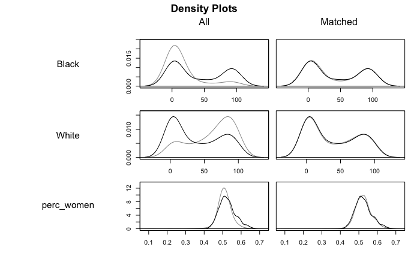

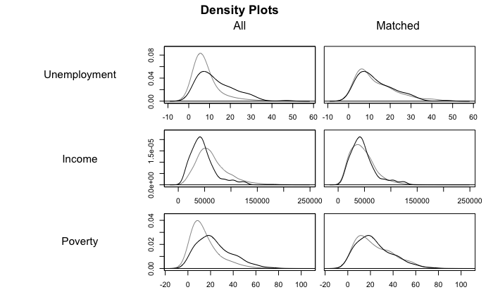

```r
plot(m.out3, type = "density", interactive = FALSE,
     which.xs = ~Black + White + perc_women + Unemployment + Income + Poverty)
```

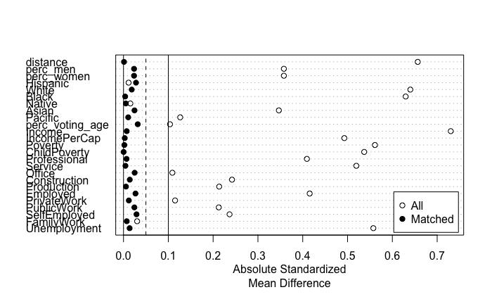

```r
plot(summary(m.out3))
```

# Results

### Estimating the treatment effect on various mobility variables using regression with just the matched data

Reminders: Treatment = mpv_treatment Dependent variable(s) = Mobility (Drive, Carpool, Transit, Walk, OtherTransp, WorkAtHome, MeanCommute) Explanatory variables = perc_men, perc_women, Hispanic, White, Black, Native, Asian, Pacific, perc_voting_age, Income, IncomePerCap, Poverty, ChildPoverty, Professional, Service, Office, Construction, Production, Employed, PrivateWork, PublicWork, SelfEmployed, FamilyWork, Unemployment

```r
# create dataframe from just matched data of model 3
matched_data_only <- match.data(m.out3)
```

### Drive – matched data

```r
model_ps_match1 <- lm(Drive ~ mpv_treatment,
                data = matched_data_only,
                weights = weights)
tidy(model_ps_match1)
```

| term | estimate | std.error | statistic | p.value |
| --- | --- | --- | --- | --- |
| (Intercept) | 67.357583 | 0.3226011 | 208.795261 | 0.0000000 |
| mpv_treatment | -2.455943 | 1.6274841 | -1.509043 | 0.1313896 |

### Carpool – matched data

```r
model_ps_match2 <- lm(Carpool ~ mpv_treatment,
                data = matched_data_only,
                weights = weights)
tidy(model_ps_match2)
```

| term | estimate | std.error | statistic | p.value |
| --- | --- | --- | --- | --- |
| (Intercept) | 8.3745367 | 0.09376238 | 89.316597 | 0.0000000 |
| mpv_treatment | -0.6728973 | 0.47302000 | -1.422556 | 0.1549655 |

### Transit – matched data

```r
model_ps_match3 <- lm(Transit ~ mpv_treatment,
                data = matched_data_only,
                weights = weights)
tidy(model_ps_match3)
```

| term | estimate | std.error | statistic | p.value |
| --- | --- | --- | --- | --- |
| (Intercept) | 15.695593 | 0.2845911 | 55.151387 | 0.0000000 |
| mpv_treatment | 2.214243 | 1.4357280 | 1.542244 | 0.1231162 |

### Walk – matched data

```r
model_ps_match4 <- lm(Walk ~ mpv_treatment,
                data = matched_data_only,
                weights = weights)
tidy(model_ps_match4)
```

| term | estimate | std.error | statistic | p.value |
| --- | --- | --- | --- | --- |
| (Intercept) | 2.9542447 | 0.09260631 | 31.901118 | 2.158955e-193 |
| mpv_treatment | 0.5170668 | 0.46718776 | 1.106764 | 2.684816e-01 |

### OtherTransp – matched data

```r
model_ps_match5 <- lm(OtherTransp ~ mpv_treatment,
                data = matched_data_only,
                weights = weights)
tidy(model_ps_match5)
```

| term | estimate | std.error | statistic | p.value |
| --- | --- | --- | --- | --- |
| (Intercept) | 1.8758238 | 0.04566824 | 41.075018 | 6.593647e-295 |
| mpv_treatment | 0.3823729 | 0.23039081 | 1.659671 | 9.708171e-02 |

### WorkAtHome – matched data

```r
model_ps_match6 <- lm(WorkAtHome ~ mpv_treatment,
                data = matched_data_only,
                weights = weights)
tidy(model_ps_match6)
```

| term | estimate | std.error | statistic | p.value |
| --- | --- | --- | --- | --- |
| (Intercept) | 3.74399337 | 0.05361514 | 69.83090439 | 0.0000000 |
| mpv_treatment | 0.01584269 | 0.27048195 | 0.05857208 | 0.9532967 |

### MeanCommute – matched data

```r
model_ps_match7 <- lm(MeanCommute ~ mpv_treatment,
                data = matched_data_only,
                weights = weights)
tidy(model_ps_match7)
```

| term | estimate | std.error | statistic | p.value |
| --- | --- | --- | --- | --- |
| (Intercept) | 30.640425 | 0.1530803 | 200.159226 | 0.00000000 |
| mpv_treatment | 1.329247 | 0.7722716 | 1.721217 | 0.08531107 |

### Drive – standard linear regression

```r
lm1 <- lm(Drive ~ mpv_treatment,
                data = census_tracts_demographics_il_with_treatment_final)
tidy(lm1)
```

| term | estimate | std.error | statistic | p.value |
| --- | --- | --- | --- | --- |
| (Intercept) | 72.256666 | 0.3112163 | 232.175048 | 0.000000e+00 |
| mpv_treatment | -7.355026 | 1.5725754 | -4.677058 | 3.034099e-06 |

### Carpool – standard linear regression

```r
lm2 <- lm(Carpool ~ mpv_treatment,
                data = census_tracts_demographics_il_with_treatment_final)
tidy(lm2)
```

| term | estimate | std.error | statistic | p.value |
| --- | --- | --- | --- | --- |
| (Intercept) | 8.2067825 | 0.08776124 | 93.512609 | 0.0000000 |
| mpv_treatment | -0.5051431 | 0.44345735 | -1.139102 | 0.2547483 |

### Transit – standard linear regression

```r
lm3 <- lm(Transit ~ mpv_treatment,
                data = census_tracts_demographics_il_with_treatment_final)
tidy(lm3)
```

| term | estimate | std.error | statistic | p.value |
| --- | --- | --- | --- | --- |
| (Intercept) | 10.222753 | 0.2421017 | 42.225033 | 1.887994e-308 |
| mpv_treatment | 7.687083 | 1.2233395 | 6.283688 | 3.766835e-10 |

### Walk – standard linear regression

```r
lm4 <- lm(Walk ~ mpv_treatment,
                data = census_tracts_demographics_il_with_treatment_final)
tidy(lm4)
```

| term | estimate | std.error | statistic | p.value |
| --- | --- | --- | --- | --- |
| (Intercept) | 3.113365 | 0.1129997 | 27.5519686 | 1.002592e-149 |
| mpv_treatment | 0.357947 | 0.5709873 | 0.6268913 | 5.307765e-01 |

### OtherTransp – standard linear regression

```r
lm5 <- lm(OtherTransp ~ mpv_treatment,
                data = census_tracts_demographics_il_with_treatment_final)
tidy(lm5)
```

| term | estimate | std.error | statistic | p.value |
| --- | --- | --- | --- | --- |
| (Intercept) | 1.8167391 | 0.04093597 | 44.380016 | 0.00000000 |
| mpv_treatment | 0.4414577 | 0.20684938 | 2.134199 | 0.03290444 |

### WorkAtHome – standard linear regression

```r
lm6 <- lm(WorkAtHome ~ mpv_treatment,
                data = census_tracts_demographics_il_with_treatment_final)
tidy(lm6)
```

| term | estimate | std.error | statistic | p.value |
| --- | --- | --- | --- | --- |
| (Intercept) | 4.3861343 | 0.05778323 | 75.906696 | 0.00000000 |
| mpv_treatment | -0.6262982 | 0.29197855 | -2.145015 | 0.03202884 |

### MeanCommute – standard linear regression

```r
lm7 <- lm(MeanCommute ~ mpv_treatment,
                data = census_tracts_demographics_il_with_treatment_final)
tidy(lm7)
```

| term | estimate | std.error | statistic | p.value |
| --- | --- | --- | --- | --- |
| (Intercept) | 28.446020 | 0.1331188 | 213.689054 | 0.000000e+00 |
| mpv_treatment | 3.523652 | 0.6723248 | 5.240997 | 1.703745e-07 |

# Discussion & limitations

Some benefits of propensity score matching include the fact that if we limit the data to observations with sufficient overlap and balance, we reduce potential bias in our inferences. An unfortunate limitation of propensity score matching is that it’s hard to know if ignorability — a crucial assumption for causal inference — is satisfied.

Still, reaching as unbiased of an estimate as possible of the treatment effect is necessary for making causal claims, even if lots of data is thrown away. Continuing research using propensity score matching to estimate causal effects on this topic would include employing sensitivity analysis and robustness checks for cases where ignorability doesn’t hold. This can strengthen our analysis, as well as using machine learning for principle component analysis to create even better balance and overlap for our matched data.